# Chess Elo Prediction — v4

Predicting White and Black Elo ratings from chess game data using a multi-task neural network. The model combines hand-crafted board/clock features with optional sequence embeddings from a pre-trained autoencoder, and outputs a full probability distribution over rating ranges rather than a single number.

**Pipeline overview:**

1. Stream and filter games from a Lichess `.pgn.zst` database
2. Extract board features (python-chess replay) and clock features — both cached to disk
3. Optionally train a sequence autoencoder and cache its embeddings
4. Train a multi-task MLP (or MLP + AE) with KL-divergence loss against soft Gaussian targets
5. Evaluate on held-out test set and visualise results
6. Run inference on a single pasted PGN game

## Config

All settings in one place. The comments explain what each flag does and what to change for laptop vs GPU.

```
Device : cpu  |  AMP : False  |  CPU threads : 14
Sequential=False  |  AE=True  |  DistTarget=True
MAX_GAMES=3,000,000  |  BATCH=128  |  LR=0.0003  |  DROPOUT=0.3
Time control filter: None  |  Min plies: 12  |  Max seq len: 120
HPO enabled
```

## Data Loading

Stream-parse the compressed PGN file. We read line by line rather than loading everything into memory, which is important for multi-million game files.

```
Loaded 3,000,000 games in 755.7s
Removed 1,007,365 games by termination type
Kept 372,502 games after filters (removed 1,611,767)
Elo range — White: 771–2605,  Black: 762–2608
```

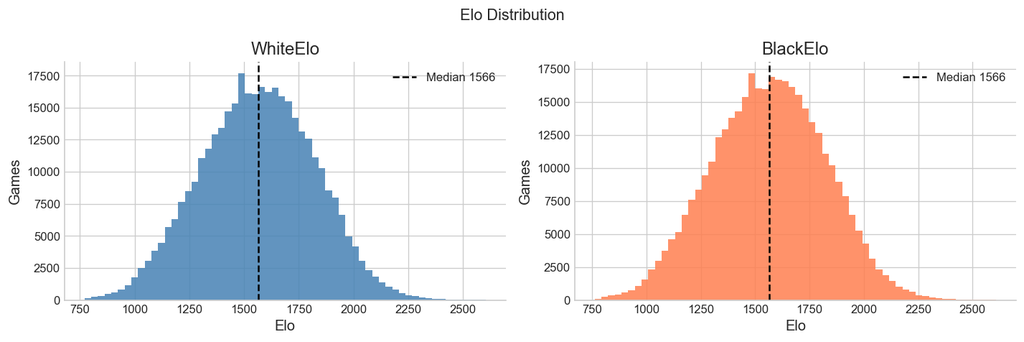

## Feature Extraction

Board features require replaying every game move-by-move with python-chess, which is slow. Both board and clock features are cached to disk — if the cache exists they load instantly.

```
Extracting board features (this runs once then caches)...
  Done in 307s — 35 cols
Extracting clock features...
  Done in 41s — 10 cols
Full feature matrix: (372502, 69)
```

## Move Tokenisation

Each unique chess move (e.g. `e4`, `Nf3`, `O-O`) gets assigned an integer ID. This is needed for the sequence model and autoencoder.

```
Dropped 6,099 games shorter than 12 plies
Vocabulary size : 9,682
Games ready     : 366,403
```

## Soft Distribution Targets

Rather than treating Elo prediction as a regression to a single number, we model each player's strength as a Gaussian distribution centred on their rating (σ=200). This reflects the real game-to-game variance in how a player performs — a 1600-rated player sometimes plays like a 1400, sometimes like an 1800.

The model outputs a 40-bin probability distribution over the range 0–4000. The point estimate is the weighted mean of that distribution. Training uses KL-divergence between predicted and target distributions.

```
1600 Elo dist: peak at 1550,  recovered = 1600
```

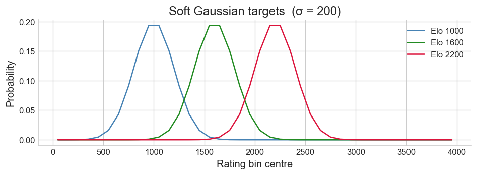

## Feature Selection, Train/Val/Test Split & Scaling

The split is stratified by Elo bracket so every rating range appears proportionally in all three sets. The scaler is fit on training data only — no information from val or test leaks into the scaling.

```
Static feature columns selected: 45
  [on ] game_structure      (3 cols)
  [on ] checks              (4 cols)
  [on ] captures            (5 cols)
  [on ] castling            (2 cols)
  [on ] style               (9 cols)
  [on ] engine_quality      (10 cols)
  [on ] clock               (10 cols)
  [on ] tc_meta             (2 cols)

Split — train: 293,122  val: 36,640  test: 36,641
Scaling done (StandardScaler fit on train only)
```

## Sequence Autoencoder

The autoencoder compresses each game's move sequence into a fixed-size vector (32 dimensions by default). It's trained once on a sample of games, then used to encode all games, and the resulting vectors are saved to disk. During main model training these cached vectors are used as extra static features, so we get sequence information without the cost of running an LSTM every training batch.

Architecture: BiLSTM encoder → 32-d bottleneck → LSTM decoder with teacher forcing.

```
Training sequence autoencoder...
  AE epoch 1/2  loss=6.5782
  AE epoch 2/2  loss=5.9326
AE embeddings saved: (366403, 32)
AE embeddings ready — 32 dims per game
```

## Dataset & DataLoaders

```
Building datasets...
  Built in 404s   total static dim = 77
Batches per epoch: 2,291
```

## Model

The model has two branches that get concatenated before prediction:

**Static branch:** MLP over board + clock features (+ AE embeddings if enabled). Uses LayerNorm and GELU activations which work well for tabular data.

**Sequence branch (optional):** Embedding → BiLSTM → soft attention pooling. Each move is represented as [embedding | normalised clock | turn flag].

**Output:** Two heads (White and Black), each predicting a softmax over 40 rating bins.

```
Model built — 1,321,393 trainable parameters
```

```
Running hyperparameter search — 20 trials on 100,000 games...
```

```
Best val loss: 0.9239
Best hyperparameters:
  lr              = 0.0009410712595063442
  dropout         = 0.18441607698962023
  hidden_dim      = 256
  embed_dim       = 64
  batch_size      = 64
  weight_decay    = 8.445950598147796e-05
```

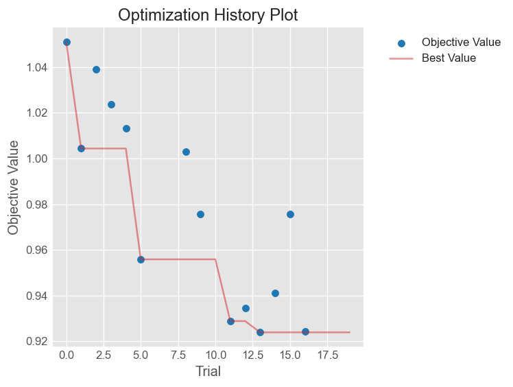

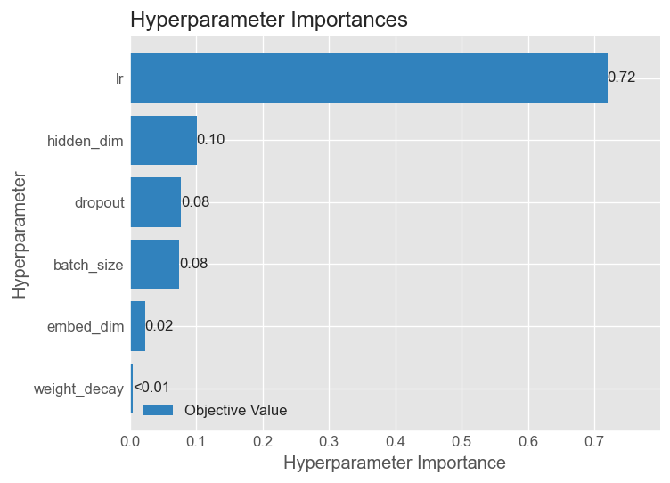

## Training

```
Using HPO parameters:
  lr              = 0.0009410712595063442
  dropout         = 0.18441607698962023
  hidden_dim      = 256
  embed_dim       = 64
  batch_size      = 64
  weight_decay    = 8.445950598147796e-05
Model rebuilt — 3,064,497 trainable parameters
Epoch  1/10  train 0.9885  val 0.9906  MAE W:198 B:196  lr 9.19e-04  62.2s
Epoch  2/10  train 1.0335  val 1.0344  MAE W:203 B:205  lr 8.56e-04  34.2s
Epoch  3/10  train 1.0024  val 1.0055  MAE W:201 B:201  lr 7.57e-04  33.3s
Epoch  4/10  train 0.9576  val 0.9616  MAE W:191 B:193  lr 6.32e-04  36.8s
Epoch  5/10  train 0.9437  val 0.9482  MAE W:191 B:190  lr 4.94e-04  32.9s
Epoch  6/10  train 0.9413  val 0.9478  MAE W:190 B:191  lr 3.56e-04  33.0s
Epoch  7/10  train 0.9493  val 0.9597  MAE W:192 B:192  lr 2.31e-04  30.1s
Epoch  8/10  train 0.9295  val 0.9422  MAE W:191 B:191  lr 1.32e-04  31.1s
Epoch  9/10  train 0.9069  val 0.9163  MAE W:187 B:187  lr 6.89e-05  29.5s
```

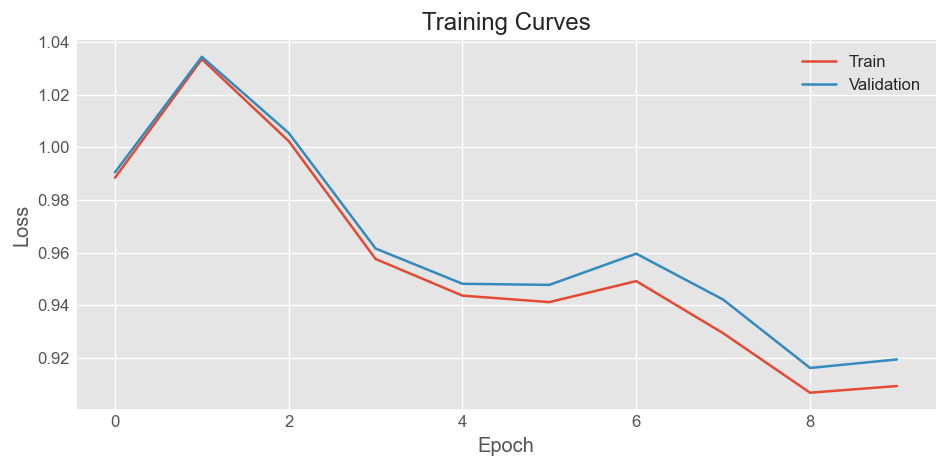

## Evaluation

```
Loaded checkpoint: chess_elo_v4_3e+06.pth
MAE    — White: 187.9  Black: 187.5  Combined: 187.7
Median — White: 155.3  Black: 155.7
Within 100 Elo: 33.8%
Within 200 Elo: 61.2%
Within 300 Elo: 79.9%
```

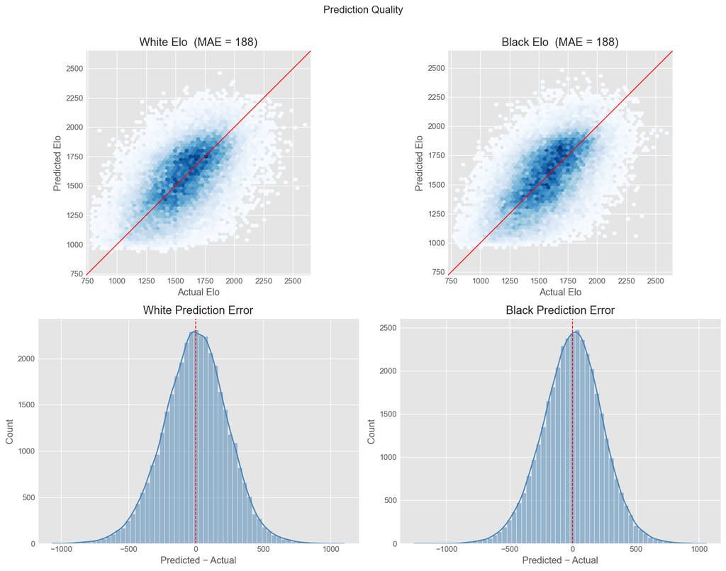

```
MAE by Elo bracket:
------------------------------------------
           (0, 1000]  MAE =   281  n = 874
        (1000, 1200]  MAE =   194  n = 5,166
        (1200, 1400]  MAE =   183  n = 13,476
        (1400, 1600]  MAE =   180  n = 20,505
        (1600, 1800]  MAE =   175  n = 19,467
        (1800, 2000]  MAE =   194  n = 10,752
        (2000, 2200]  MAE =   266  n = 2,639
        (2200, 2500]  MAE =   404  n = 396
        (2500, 4000]  MAE =   703  n = 7
```

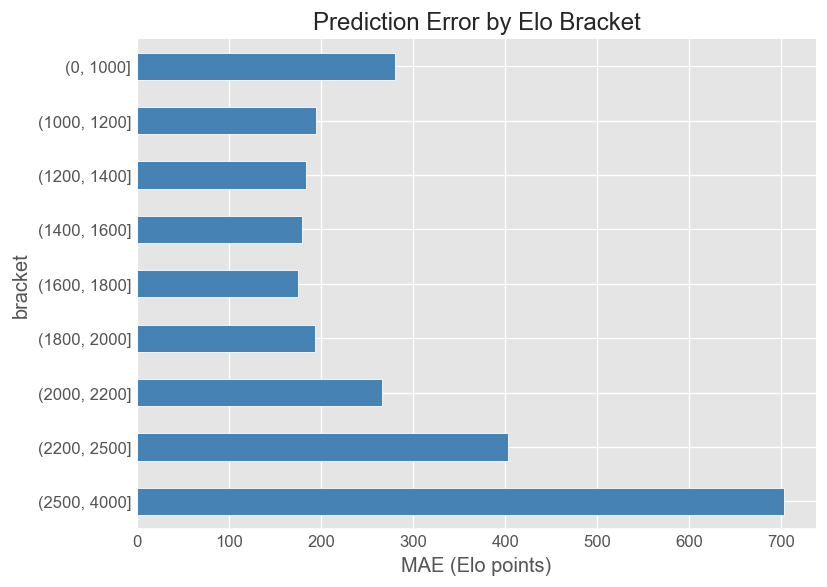

## Predicted Rating Distributions

One of the nicest things about the distribution output: instead of just getting a number, you see the full probability mass the model assigns across the rating range. A narrow peak means the model is confident; a wide spread means it's uncertain.

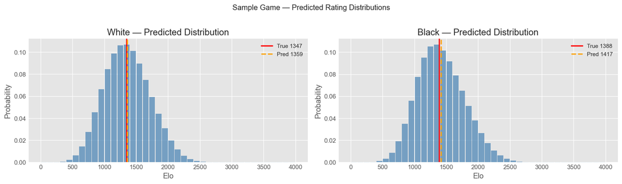

## Latent Space — t-SNE & PCA

Are games with similar Elo ratings close together in the model's internal representation?

```
Running t-SNE on 3000 vectors...
```

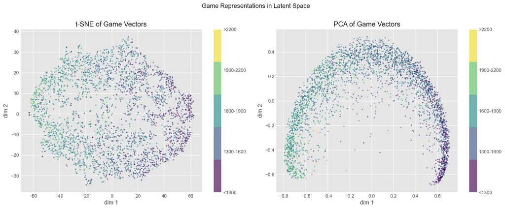

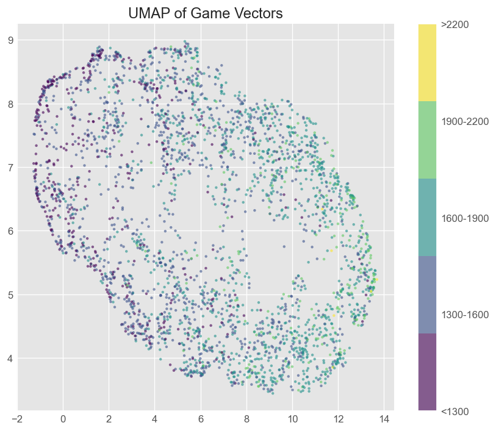

### AE Embedding Space

Same visualisation but using the raw AE embeddings before the main model sees them.

```
Running t-SNE on 3000 AE embeddings...
```

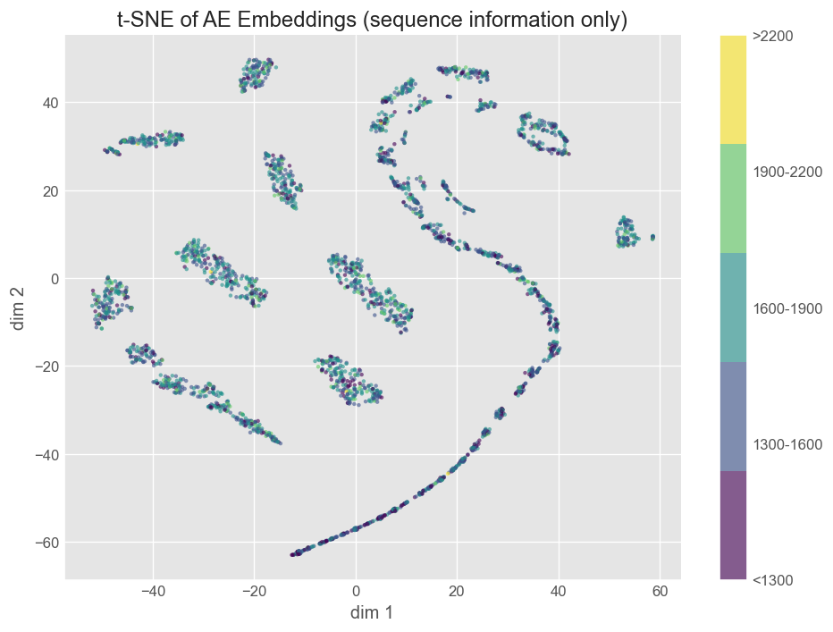

## Feature Group Importance

Zero out each feature group in turn and measure how much worse the MAE gets.

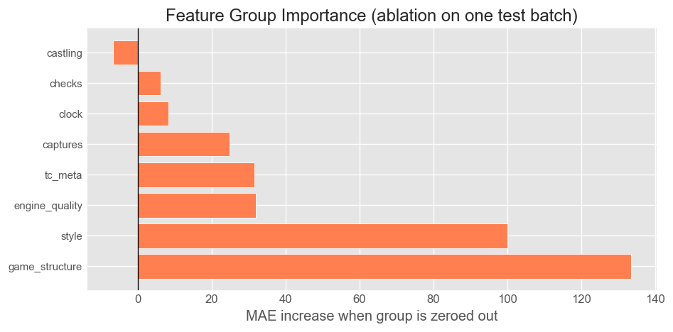

```
  game_structure      Δ = +133.4
  style               Δ = +100.1
  engine_quality      Δ = +31.9
  tc_meta             Δ = +31.6
  captures            Δ = +24.8
  clock               Δ = +8.2
  checks              Δ = +6.1
  castling            Δ = -6.8
```

## Opening Analysis (ECO codes)

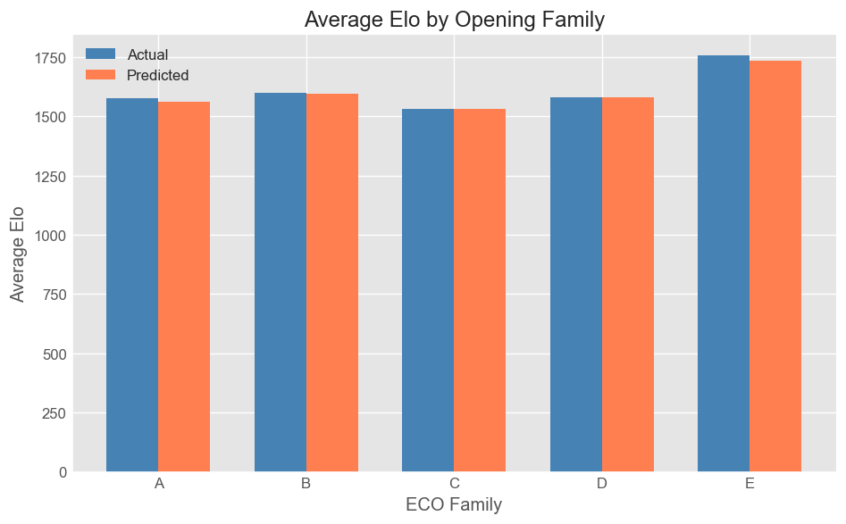

```
Top 5 highest-Elo ECO codes (min 10 games):
    C05  avg Elo: 1952  (n=20)
    C03  avg Elo: 1926  (n=12)
    C18  avg Elo: 1917  (n=10)
    B41  avg Elo: 1909  (n=16)
    C07  avg Elo: 1894  (n=10)

Bottom 5 lowest-Elo ECO codes (min 10 games):
    C20  avg Elo: 1394  (n=1897)
    C27  avg Elo: 1407  (n=114)
    C49  avg Elo: 1413  (n=17)
    C40  avg Elo: 1446  (n=984)
    C47  avg Elo: 1460  (n=107)
```

## Anomaly Detection

Games where the model's estimate differs most from actual rating — potential over/underperformers.

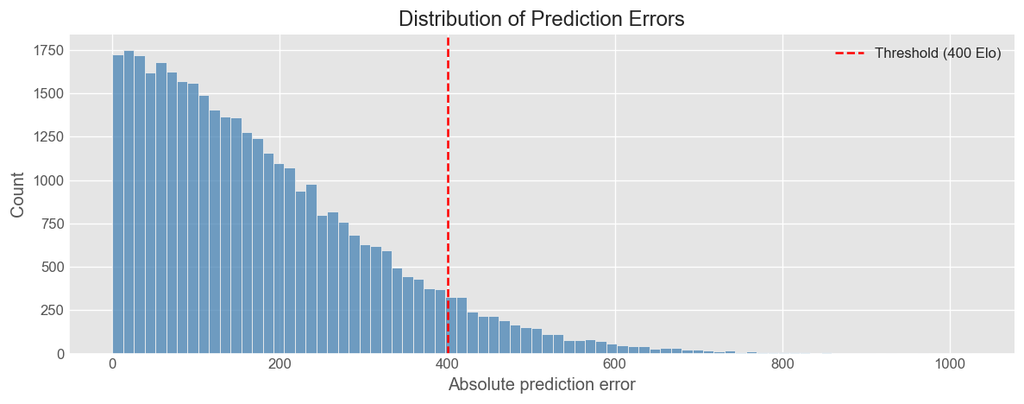

```
Flagged 2906 games with error > 400 Elo  (7.9%)

Top 15 OVERPERFORMERS  (model rates them higher than actual)
   Predicted      Actual      Diff
  --------------------------------
        1923         924      +999
        2208        1238      +970
        2132        1205      +927
        2166        1280      +886
        2087        1211      +876
        2148        1276      +872
        2120        1259      +861
        1927        1080      +848
        2032        1200      +831
        2064        1244      +820
```

[output cut: 24 more lines]

## Single-Game Inference

Paste any PGN below and run the cell. Works with Lichess and chess.com exports. If the PGN has `[WhiteElo]` and `[BlackElo]` headers, the actual ratings are shown for comparison.

Note: this model was trained on Lichess ratings. Chess.com ratings tend to run ~100-200 points lower for the same strength player, so predictions on chess.com games may be slightly high.

```
=============================================
  White Elo   predicted:  1857   actual: 1546
  Black Elo   predicted:  1797   actual: 1534
=============================================
```

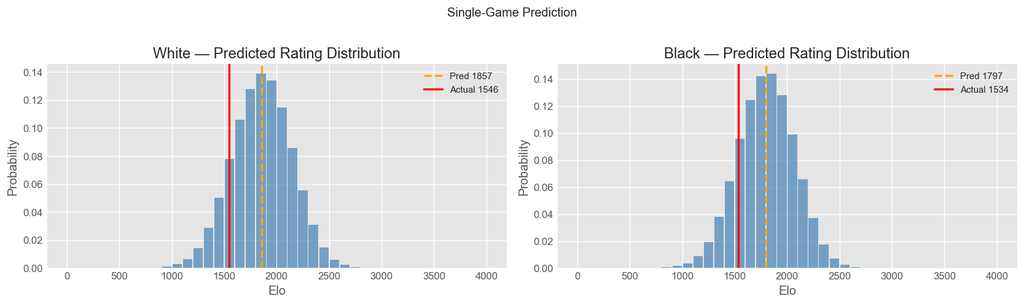

## Export

Press `Ctrl+S` to save the notebook, then run this cell.

```
Exported: c:\CodeBases\AppML_FinalProject\root\workspace\elias_sandbox\output_files\chess_elo_v4_3e+06_20260606_203537.html
```